# BioinfoFinalRScript

```r
all.equal(plantNameGivenOriginal, plantNameGivenNinety,plantNameGivenOneEighty,plantNameGivenTwoSeventy)
```

```
## [1] TRUE
```

This is based on antoher data set that applied slightly different algorithm. This was not throughly mentioned in the paper p-value is 0.0001605

```r
dataModel <- read.table(file="c:/Users/Autumn/Downloads/imageResult/results-dataset-model-47398.tsv", header=TRUE, sep="\t")
print(dataModel)
```

```
##                                                 Label Straight.Prediction
## 1              Tomato - Tomato_Yellow_Leaf_Curl_Virus           0.9979466
## 2                        Tomato - Tomato_mosaic_virus           1.0000000
## 3                                Tomato - Target_Spot           0.8789174
## 4       Tomato - Spider_mites Two-spotted_spider_mite           0.9403341
## 5                         Tomato - Septoria_leaf_spot           0.9983060
## 6                                  Tomato - Leaf_Mold           0.9642857
## 7                                Tomato - Late_blight           0.9790466
## 8                                    Tomato - healthy           0.9453174
## 9                               Tomato - Early_blight           0.7880000
## 10                            Tomato - Bacterial_spot           0.6563235
## 11                           Strawberry - Leaf_scorch           0.9990983
## 12                               Strawberry - healthy           1.0000000
## 13                               Potato - Late_blight           0.9850000
## 14                                   Potato - healthy           1.0000000
```

[output cut: 53 more lines]

```r
straightModel <- dataModel[,2]
plantNameGivenModel <- dataModel[,3]
wilcox.test(plantNameGivenModel, straightModel, paired=TRUE, alternative ="g")
```

```
##
##  Wilcoxon signed rank test with continuity correction
##
## data:  plantNameGivenModel and straightModel
## V = 153, p-value = 0.0001605
## alternative hypothesis: true location shift is greater than 0
```

```r
dataModelNew <- read.table(file="c:/Users/Autumn/Downloads/imageResult/results-new-images.tsv", header=TRUE, sep="\t")
print(dataModelNew)
```

```
##                                                 Label Straight.Prediction
## 1                                  Apple - Apple_scab          0.18181818
## 2                                   Apple - Black_rot          0.15384615
## 3                            Apple - Cedar_apple_rust          0.08333333
## 4                                     Apple - healthy          0.20000000
## 5                   Cherry_(including_sour) - healthy          0.00000000
## 6  Corn_(maize) - Cercospora_leaf_spot Gray_leaf_spot          0.62500000
## 7                         Corn_(maize) - Common_rust_          0.30000000
## 8                              Corn_(maize) - healthy          0.40000000
## 9                 Corn_(maize) - Northern_Leaf_Blight          0.30000000
## 10                                  Grape - Black_rot          0.00000000
## 11                       Grape - Esca_(Black_Measles)          0.23076923
## 12                                    Grape - healthy          0.40000000
## 13         Grape - Leaf_blight_(Isariopsis_Leaf_Spot)          0.00000000
## 14                             Peach - Bacterial_spot          0.30000000
```

[output cut: 51 more lines]

```r
straightNew <- dataModelNew[,2]
plantNameGivenNew <- dataModelNew[,3]
wilcox.test(plantNameGivenNew, straightNew, paired=TRUE, alternative ="g")
```

```
##
##  Wilcoxon signed rank test with continuity correction
##
## data:  plantNameGivenNew and straightNew
## V = 300, p-value = 9.636e-06
## alternative hypothesis: true location shift is greater than 0
```

```r
deltaCostNew <- abs(plantNameGivenNew - straightNew)
deltaCostModel <- abs(plantNameGivenModel - straightModel)
deltaCostOriginal <- abs(plantNameGivenOriginal - straightOriginal)

deltaCostNew
```

```
##  [1] 0.63636364 0.30769231 0.25000000 0.70000000 0.33333333 0.25000000
##  [7] 0.20000000 0.30000000 0.00000000 0.40000000 0.76923077 0.50000000
## [13] 0.80000000 0.70000000 0.23076923 0.90000000 0.00000000 0.63636364
## [19] 0.30000000 0.20000000 0.10000000 0.00000000 0.00000000 0.25000000
## [25] 0.00000000 0.40000000 0.09090909 0.50000000 0.00000000 0.00000000
## [31] 0.44444444 0.00000000
```

```r
deltaCostModel
```

```
##  [1] 0.000000000 0.000000000 0.000000000 0.000000000 0.000000000
##  [6] 0.000000000 0.000000000 0.004399749 0.000000000 0.000470146
## [11] 0.000901713 0.000000000 0.007000000 0.000000000 0.088000000
## [16] 0.000676590 0.000000000 0.000000000 0.000000000 0.103159851
## [21] 0.000000000 0.000723066 0.002542373 0.001015228 0.000000000
## [26] 0.000838926 0.001949318 0.003802281 0.001170960 0.017021277
## [31] 0.029090909 0.000000000 0.003174603
```

```r
deltaCostOriginal
```

```
##  [1] 0.003174603 0.000000000 0.029090909 0.016413374 0.001170960
##  [6] 0.003802281 0.001949318 0.000000000 0.000000000 0.001015229
## [11] 0.002542373 0.000723066 0.000000000 0.098513011 0.000000000
## [16] 0.000000000 0.000000000 0.000676590 0.087000000 0.000000000
## [21] 0.007000000 0.000000000 0.000901713 0.000940292 0.000000000
## [26] 0.004399749 0.000000000 0.000000000 0.000000000 0.000000000
## [31] 0.000000000 0.000000000 0.000000000
```

```r
mean(deltaCostNew)
```

```
## [1] 0.3187221
```

```r
mean(deltaCostModel)
```

```
## [1] 0.008058697
```

```r
mean(deltaCostOriginal)
```

```
## [1] 0.007857984
```

Same dataset as the “original”, but parsed the number of pictures used

```r
df <- read.table(file="c:/Users/Autumn/Downloads/imageResult/original.tsv", header=TRUE, sep="\t")
print(df)
```

```
##                                                 Label Straight.Prediction
## 1                                  Apple - Apple_scab           0.9952381
## 2                                   Apple - Black_rot           1.0000000
## 3                            Apple - Cedar_apple_rust           0.9636364
## 4                                     Apple - healthy           0.9823708
## 5                   Cherry_(including_sour) - healthy           0.9976581
## 6            Cherry_(including_sour) - Powdery_mildew           0.9961977
## 7  Corn_(maize) - Cercospora_leaf_spot Gray_leaf_spot           0.8479532
## 8                         Corn_(maize) - Common_rust_           1.0000000
## 9                              Corn_(maize) - healthy           1.0000000
## 10                Corn_(maize) - Northern_Leaf_Blight           0.9908629
## 11                                  Grape - Black_rot           0.9966102
## 12                       Grape - Esca_(Black_Measles)           0.9985539
## 13                                    Grape - healthy           1.0000000
## 14         Grape - Leaf_blight_(Isariopsis_Leaf_Spot)           0.9014870
```

[output cut: 53 more lines]

```r
straightDF <- df[,2]
plantNameGivenDF <- df[,3]
wilcox.test(plantNameGivenDF, straightDF, paired=TRUE, alternative ="g")
```

```
##
##  Wilcoxon signed rank test with continuity correction
##
## data:  plantNameGivenDF and straightDF
## V = 136, p-value = 0.0002412
## alternative hypothesis: true location shift is greater than 0
```

```r
library("reshape2")
library("ggplot2")
```

# Since the data was not tidy, we made the data tidy here

```r
test_data_long <- melt(df, id="Label")  # convert to long format
test_data_long
```

```
##                                                 Label            variable
## 1                                  Apple - Apple_scab Straight.Prediction
## 2                                   Apple - Black_rot Straight.Prediction
## 3                            Apple - Cedar_apple_rust Straight.Prediction
## 4                                     Apple - healthy Straight.Prediction
## 5                   Cherry_(including_sour) - healthy Straight.Prediction
## 6            Cherry_(including_sour) - Powdery_mildew Straight.Prediction
## 7  Corn_(maize) - Cercospora_leaf_spot Gray_leaf_spot Straight.Prediction
## 8                         Corn_(maize) - Common_rust_ Straight.Prediction
## 9                              Corn_(maize) - healthy Straight.Prediction
## 10                Corn_(maize) - Northern_Leaf_Blight Straight.Prediction
## 11                                  Grape - Black_rot Straight.Prediction
## 12                       Grape - Esca_(Black_Measles) Straight.Prediction
## 13                                    Grape - healthy Straight.Prediction
## 14         Grape - Leaf_blight_(Isariopsis_Leaf_Spot) Straight.Prediction
```

[output cut: 119 more lines]

plot the chart

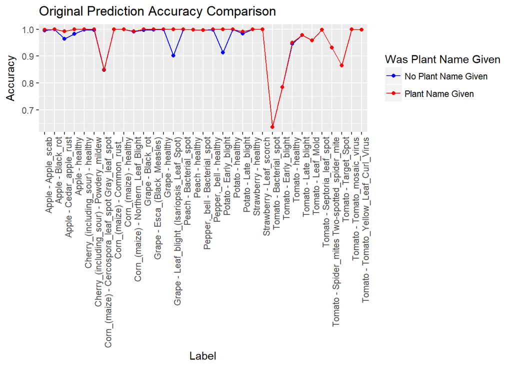

```r
originalPlot <-ggplot(test_data_long, aes(Label, value, color = variable, group =variable)) +
  geom_point() +
  geom_line()  + theme(axis.text.x = element_text(angle = 90, hjust = 1)) +
  labs(y = "Accuracy", title = "Original Prediction Accuracy Comparison")+
  scale_color_manual(labels = c("No Plant Name Given", "Plant Name Given"), values = c("blue", "red"))+
  guides(color=guide_legend("Was Plant Name Given"))
#next two line commented lines can be used when we want to replace the x-axis to numeric value to focus on trend
#rather than actual labels
#+
#  scale_color_manual(labels = c("Plant Not Given", "Plant Given"), values = c("blue", "red"))
originalPlot
```

```r
dfModel <- read.table(file="c:/Users/Autumn/Downloads/imageResult/model.tsv", header=TRUE, sep="\t")
print(dfModel)
```

```
##                                                 Label Straight.Prediction
## 1              Tomato - Tomato_Yellow_Leaf_Curl_Virus           0.9979466
## 2                        Tomato - Tomato_mosaic_virus           1.0000000
## 3                                Tomato - Target_Spot           0.8789174
## 4       Tomato - Spider_mites Two-spotted_spider_mite           0.9403341
## 5                         Tomato - Septoria_leaf_spot           0.9983060
## 6                                  Tomato - Leaf_Mold           0.9642857
## 7                                Tomato - Late_blight           0.9790466
## 8                                    Tomato - healthy           0.9453174
## 9                               Tomato - Early_blight           0.7880000
## 10                            Tomato - Bacterial_spot           0.6563235
## 11                           Strawberry - Leaf_scorch           0.9990983
## 12                               Strawberry - healthy           1.0000000
## 13                               Potato - Late_blight           0.9850000
## 14                                   Potato - healthy           1.0000000
```

[output cut: 53 more lines]

```r
straightDFModel <- dfModel[,2]
plantNameGivenDFModel <- dfModel[,3]
wilcox.test(plantNameGivenDFModel, straightDFModel, paired=TRUE, alternative ="g")
```

```
##
##  Wilcoxon signed rank test with continuity correction
##
## data:  plantNameGivenDFModel and straightDFModel
## V = 153, p-value = 0.0001605
## alternative hypothesis: true location shift is greater than 0
```

Since the data was not tidy, we made the data tidy here

```r
test_data_longModel <- melt(dfModel, id="Label")
```

plot the chart

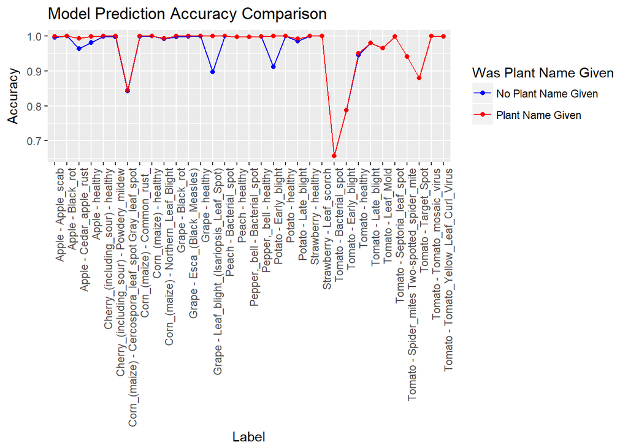

```r
modelPlot <-ggplot(test_data_longModel, aes(Label, value, color = variable, group =variable)) +
  geom_point() +
  geom_line()  + theme(axis.text.x = element_text(angle = 90, hjust = 1))+
  labs(y = "Accuracy", title = "Model Prediction Accuracy Comparison")+
  scale_color_manual(labels = c("No Plant Name Given", "Plant Name Given"), values = c("blue", "red"))+
  guides(color=guide_legend("Was Plant Name Given"))

modelPlot
```

Same dataset as the “DataModelNew”, but parsed the number of pictures used

```r
dfNew <- read.table(file="c:/Users/Autumn/Downloads/imageResult/new.tsv", header=TRUE, sep="\t")
print(dfNew)
```

```
##                                                 Label Straight.Prediction
## 1                                  Apple - Apple_scab          0.18181818
## 2                                   Apple - Black_rot          0.15384615
## 3                            Apple - Cedar_apple_rust          0.08333333
## 4                                     Apple - healthy          0.20000000
## 5                   Cherry_(including_sour) - healthy          0.00000000
## 6  Corn_(maize) - Cercospora_leaf_spot Gray_leaf_spot          0.62500000
## 7                         Corn_(maize) - Common_rust_          0.30000000
## 8                              Corn_(maize) - healthy          0.40000000
## 9                 Corn_(maize) - Northern_Leaf_Blight          0.30000000
## 10                                  Grape - Black_rot          0.00000000
## 11                       Grape - Esca_(Black_Measles)          0.23076923
## 12                                    Grape - healthy          0.40000000
## 13         Grape - Leaf_blight_(Isariopsis_Leaf_Spot)          0.00000000
## 14                             Peach - Bacterial_spot          0.30000000
```

[output cut: 51 more lines]

```r
straightDFNew <- dfNew[,2]
plantNameGivenDFNew <- dfNew[,3]
labelDFNew<-dfNew[,1]
wilcox.test(plantNameGivenDFNew, straightDFNew, paired=TRUE, alternative ="g")
```

```
##
##  Wilcoxon signed rank test with continuity correction
##
## data:  plantNameGivenDFNew and straightDFNew
## V = 300, p-value = 9.636e-06
## alternative hypothesis: true location shift is greater than 0
```

Since the data was not tidy, we made the data tidy here

```r
test_data_longNew <- melt(dfNew, id="Label")
```

plot the chart

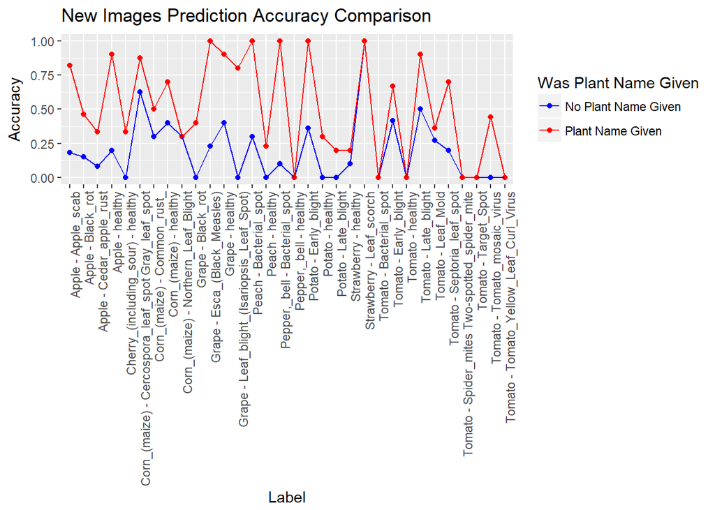

```r
newPlot <-ggplot(test_data_longNew, aes(Label, value, color = variable, group =variable)) +
  geom_point() +
  geom_line()  + theme(axis.text.x = element_text(hjust = 1))+
  labs(y = "Accuracy", title = "New Images Prediction Accuracy Comparison")+
  scale_color_manual(labels = c("No Plant Name Given", "Plant Name Given"), values = c("blue", "red"))+
  guides(color=guide_legend("Was Plant Name Given"))+
  theme(axis.text.x = element_text(angle = 90, hjust = 1))

newPlot
```

Below mean functions are used to analyze general mean accuracy

```r
mean(straightOriginal)
```

```
## [1] 0.9591374
```

```r
mean(plantNameGivenOriginal)
```

```
## [1] 0.9669954
```

```r
mean(straightNinety)
```

```
## [1] 0.9591374
```

```r
mean(plantNameGivenNinety)
```

```
## [1] 0.9669954
```

```r
mean(straightDF)
```

```
## [1] 0.9591374
```

```r
mean(plantNameGivenDF)
```

```
## [1] 0.9669954
```

```r
mean(straightNew)
```

```
## [1] 0.1914937
```

```r
mean(plantNameGivenNew)
```

```
## [1] 0.5102157
```